# raw 데이터 탐색

올림푸스

2020-04-24

# 고객 데이터 탐색

## 고객 확인

```r
class(df_client)
```

```
## [1] "data.frame"
```

```r
mode(df_client)
```

```
## [1] "list"
```

```r
dim(df_client)
```

```
## [1] 671679      3
```

```r
str(df_client)
```

```
## 'data.frame':    671679 obs. of  3 variables:
##  $ CLNT_ID : num  3736122 3736191 3738689 3738963 3739149 ...
##  $ CLNT_GEN: chr  "F" "F" "F" "M" ...
##  $ CLNT_AGE: num  30 40 40 30 30 30 20 30 30 30 ...
##  - attr(*, "spec")=List of 3
##   ..$ cols   :List of 3
##   .. ..$ CLNT_ID : list()
##   .. .. ..- attr(*, "class")= chr  "collector_double" "collector"
##   .. ..$ CLNT_GEN: list()
##   .. .. ..- attr(*, "class")= chr  "collector_character" "collector"
##   .. ..$ CLNT_AGE: list()
##   .. .. ..- attr(*, "class")= chr  "collector_double" "collector"
##   ..$ default: list()
##   .. ..- attr(*, "class")= chr  "collector_guess" "collector"
##   ..$ skip   : num 1
##   ..- attr(*, "class")= chr "col_spec"
```

```r
summary(df_client)
```

```
##     CLNT_ID          CLNT_GEN            CLNT_AGE
##  Min.   :      8   Length:671679      Min.   :10.00
##  1st Qu.:1682104   Class :character   1st Qu.:30.00
##  Median :3382071   Mode  :character   Median :30.00
##  Mean   :3370591                      Mean   :33.06
##  3rd Qu.:5087683                      3rd Qu.:40.00
##  Max.   :6592553                      Max.   :80.00
```

```r
# 성별 / 연령별 고객 수
table(df_client$CLNT_GEN, df_client$CLNT_AGE)
```

```
##
##         10     20     30     40     50     60     70     80
##   F   3007  82269 271712 180398  28881   3784    542     23
##   M    800  13028  41888  35819   7743   1472    304      9
```

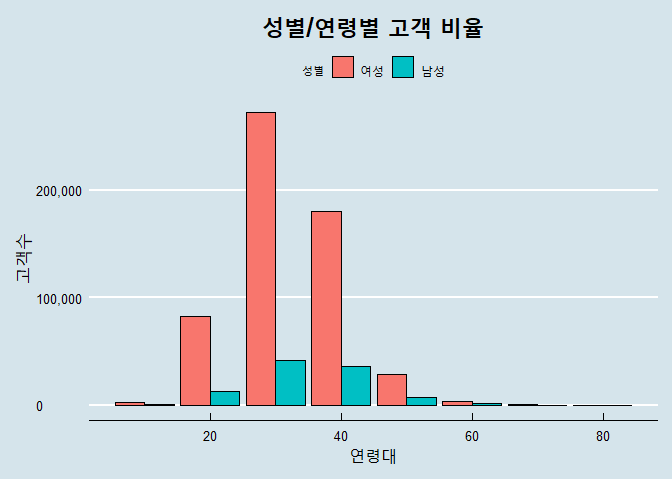

```r
# 성별 / 연령별 고객 비율 시각화
library(ggplot2)
library(ggthemes)
library(scales)

ggplot(data = df_client) +
  geom_bar(mapping = aes(x=CLNT_AGE, fill=CLNT_GEN), position = 'dodge', col = 'black') +
  scale_fill_discrete(name='성별', labels = c('여성', '남성')) +
  labs(title = '성별/연령별 고객 비율', x = '연령대', y = '고객수') +
  theme_economist() +
  theme(plot.title = element_text(face = 'bold', hjust = 0.5, size = 20, color = 'black')) +
  theme(axis.title = element_text(size = 16, color = 'black')) +
  scale_y_continuous(labels = scales::comma)
```

- 20 ~ 40대 여성이 주 고객층임을 확인할 수 있다.

## 성별 고객 주문 탐색

```r
library(dplyr)
( gen_tot <- clnt_order %>%
    group_by(CLNT_GEN) %>%
    summarise(TOT_GEN = sum(PD_BUY_TOT),  # 성별 매출액 총합
              CNT_GEN = sum(PD_BUY_CT),   # 성별 매출수량 총합
              AVG_CNT_GEN = mean(PD_BUY_CT)) %>%  # 성별 매출수량 평균
    mutate(AVG_TOT_GEN = TOT_GEN / CNT_GEN) # 성별 매출액 평균
)
```

```
## # A tibble: 2 x 5
##   CLNT_GEN      TOT_GEN CNT_GEN AVG_CNT_GEN AVG_TOT_GEN
##   <chr>           <dbl>   <dbl>       <dbl>       <dbl>
## 1 F        179901374980 3998702        1.15      44990.
## 2 M         31247512191  589631        1.19      52995.
```

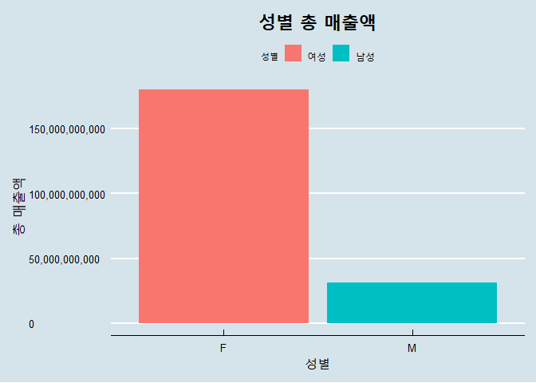

```r
# 성별 총 매출액 시각화
ggplot(data = gen_tot) +
  geom_bar(mapping = aes(x= CLNT_GEN, y = TOT_GEN, fill = CLNT_GEN), stat = 'identity') +
  scale_fill_discrete(name='성별', labels = c('여성', '남성')) +
  labs(title = '성별 총 매출액', x = '성별', y = '총 매출액') +
  theme_economist() +
  theme(plot.title = element_text(face = 'bold', hjust = 0.5, size = 20, color = 'black')) +
  theme(axis.title = element_text(size = 16, color = 'black')) +
  scale_y_continuous(labels = scales::comma)
```

- 여성의 총 매출액이 약 5.76배 큼, 그러나 고객 수 자체가 여성이 많아 크게 나온 값이므로, 평균값 그래프로 그려봐야 함.

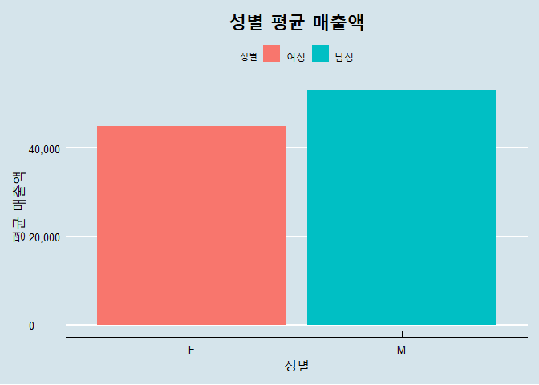

```r
# 성별 평균 매출액 시각화

ggplot(data=gen_tot) +
  geom_bar(mapping = aes(x= CLNT_GEN, y = AVG_TOT_GEN, fill = CLNT_GEN), stat = 'identity') +
  scale_fill_discrete(name='성별', labels = c('여성', '남성')) +
  labs(title = '성별 평균 매출액', x = '성별', y = '평균 매출액') +
  theme_economist() +
  theme(plot.title = element_text(face = 'bold', hjust = 0.5, size = 20, color = 'black')) +
  theme(axis.title = element_text(size = 16, color = 'black')) +
  scale_y_continuous(labels = scales::comma)
```

- 평균 매출액의 경우 오히려 남성이 더 큼

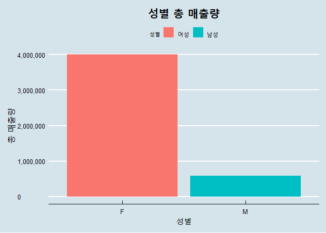

```r
# 성별 총 매출량 시각화
ggplot(data = gen_tot) +
  geom_bar(mapping = aes(x= CLNT_GEN, y = CNT_GEN, fill = CLNT_GEN), stat = 'identity') +
  scale_fill_discrete(name='성별', labels = c('여성', '남성')) +
  labs(title = '성별 총 매출량', x = '성별', y = '총 매출량') +
  theme_economist() +
  theme(plot.title = element_text(face = 'bold', hjust = 0.5, size = 20, color = 'black')) +
  theme(axis.title = element_text(size = 16, color = 'black')) +
  scale_y_continuous(labels = scales::comma)
```

- 여성의 총 매출량이 약 6.78배 큼, 그러나 고객 수 자체가 커 크게 나온 값, 평균값으로 시각화할 필요가 있음.

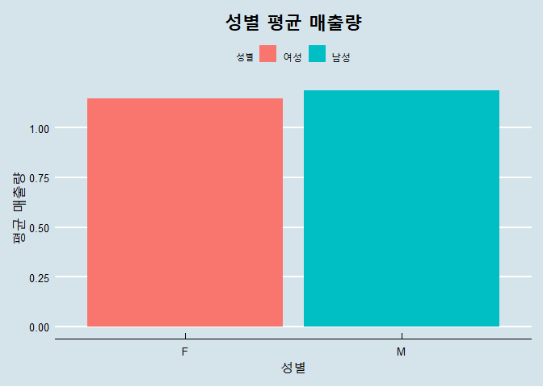

```r
# 성별 평균 매출량 시각화
ggplot(data=gen_tot) +
  geom_bar(mapping = aes(x= CLNT_GEN, y = AVG_CNT_GEN, fill = CLNT_GEN), stat = 'identity') +
  scale_fill_discrete(name='성별', labels = c('여성', '남성')) +
  labs(title = '성별 평균 매출량', x = '성별', y = '평균 매출량') +
  theme_economist() +
  theme(plot.title = element_text(face = 'bold', hjust = 0.5, size = 20, color = 'black')) +
  theme(axis.title = element_text(size = 16, color = 'black')) +
  scale_y_continuous(labels = scales::comma)
```

- 평균 매출량의 경우, 미미한 차이이나 남성이 더 큼.

```r
# 성별 최고 매출 TOP5 대분류 제품군 담고 있는 dataframe 생성
( genamt_top_clac <-
    clnt_proorder %>%
      group_by(CLNT_GEN, CLAC1_NM) %>%
      summarise(SALES = sum(PD_BUY_TOT)) %>%
      arrange(CLNT_GEN, desc(SALES)) %>%
      group_by(CLNT_GEN) %>%
      slice(1:5) )
```

```
## # A tibble: 10 x 3
## # Groups:   CLNT_GEN [2]
##    CLNT_GEN CLAC1_NM              SALES
##    <chr>    <chr>                 <dbl>
##  1 F        패션잡화        32573080580
##  2 F        여성의류        26705752640
##  3 F        화장품/뷰티케어 20654151830
##  4 F        스포츠패션      18327612720
##  5 F        남성의류         9977418990
##  6 M        스포츠패션       5098726950
##  7 M        패션잡화         4684195820
##  8 M        남성의류         3939111080
##  9 M        화장품/뷰티케어  1920293630
## 10 M        가구             1884343320
```

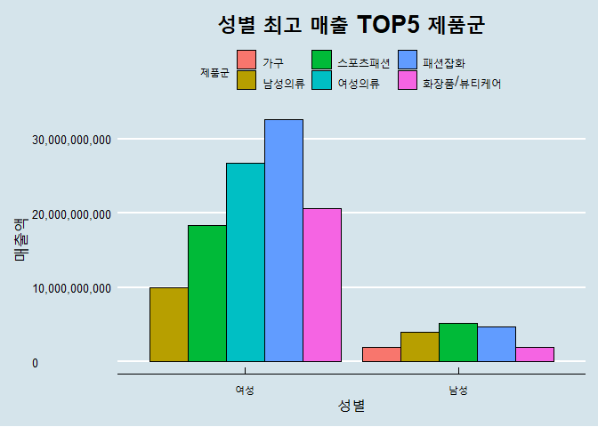

```r
# 성별 최고 매출 TOP5 대분류 제품군 시각화
ggplot(data = genamt_top_clac) +
  geom_bar(mapping = aes(x=CLNT_GEN, y = SALES, fill = CLAC1_NM), position = 'dodge', stat = 'identity', col = 'black') +
  labs(title = '성별 최고 매출 TOP5 제품군', x = '성별', y = '매출액', fill = '제품군') +
  scale_x_discrete(name='성별', labels = c('여성', '남성')) +
  theme_economist() +
  theme(plot.title = element_text(face = 'bold', hjust = 0.5, size = 20, color = 'black')) +
  theme(axis.title = element_text(size = 16, color = 'black')) +
  scale_y_continuous(labels = scales::comma)
```

```r
# 성별 최고 매출 TOP5 브랜드 담고 있는 dataframe 생성
( genamt_top_brand <-
    clnt_proorder %>%
      group_by(CLNT_GEN, PD_BRA_NM) %>%
      summarise(SALES = sum(PD_BUY_TOT)) %>%
      arrange(CLNT_GEN, desc(SALES)) %>%
      group_by(CLNT_GEN) %>%
      slice(1:5) )
```

```
## # A tibble: 10 x 3
## # Groups:   CLNT_GEN [2]
##    CLNT_GEN PD_BRA_NM      SALES
##    <chr>    <chr>          <dbl>
##  1 F        LG전자    6163199250
##  2 F        정관장    3591567040
##  3 F        프라다    2547859370
##  4 F        삼성전자  2310557490
##  5 F        나이키    2110920110
##  6 M        LG전자    1614165411
##  7 M        나이키    1028864440
##  8 M        정관장     755246130
##  9 M        삼성전자   686644320
## 10 M        프라다     466071740
```

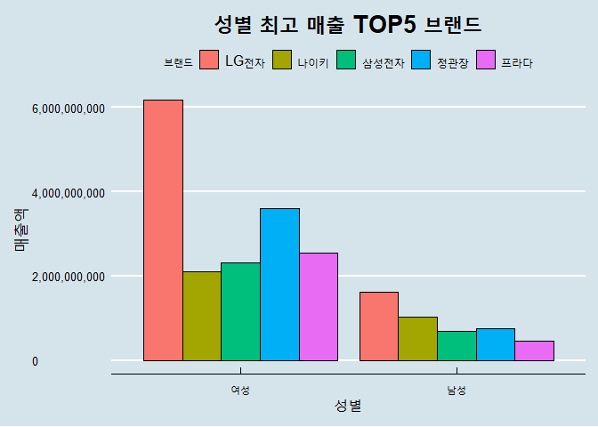

```r
# 성별 최고 매출 TOP5 브랜드 시각화
ggplot(data = genamt_top_brand) +
  geom_bar(mapping = aes(x=CLNT_GEN, y = SALES, fill = PD_BRA_NM), position = 'dodge', stat = 'identity', col = 'black') +
  labs(title = '성별 최고 매출 TOP5 브랜드', x = '성별', y = '매출액', fill = '브랜드') +
  scale_x_discrete(name='성별', labels = c('여성', '남성')) +
  theme_economist() +
  theme(plot.title = element_text(face = 'bold', hjust = 0.5, size = 20, color = 'black')) +
  theme(axis.title = element_text(size = 16, color = 'black')) +
  scale_y_continuous(labels = scales::comma)
```

```r
# 성별 최다 판매 TOP5 브랜드 담고 있는 dataframe 생성
( gencnt_top_brand <-
    clnt_proorder %>%
      group_by(CLNT_GEN, PD_BRA_NM) %>%
      summarise(SALES = sum(PD_BUY_CT)) %>%
      arrange(CLNT_GEN, desc(SALES)) %>%
      group_by(CLNT_GEN) %>%
      slice(1:5) )
```

```
## # A tibble: 10 x 3
## # Groups:   CLNT_GEN [2]
##    CLNT_GEN PD_BRA_NM    SALES
##    <chr>    <chr>        <dbl>
##  1 F        지오다노     59344
##  2 F        나이키       34461
##  3 F        에이치커넥트 30261
##  4 F        정관장       29005
##  5 F        크록스       27483
##  6 M        지오다노     17556
##  7 M        나이키       14572
##  8 M        한샘          8307
##  9 M        탑텐          6603
## 10 M        정관장        5740
```

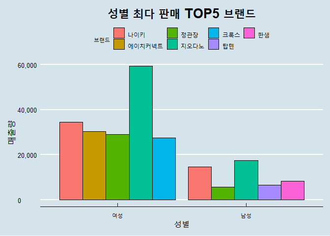

```r
# 성별 최다 판매 TOP5 브랜드 시각화
ggplot(data = gencnt_top_brand) +
  geom_bar(mapping = aes(x=CLNT_GEN, y = SALES, fill = PD_BRA_NM), position = 'dodge', stat = 'identity', col = 'black') +
  labs(title = '성별 최다 판매 TOP5 브랜드', x = '성별', y = '매출량', fill = '브랜드') +
  scale_x_discrete(name='성별', labels = c('여성', '남성')) +
  theme_economist() +
  theme(plot.title = element_text(face = 'bold', hjust = 0.5, size = 20, color = 'black')) +
  theme(axis.title = element_text(size = 16, color = 'black')) +
  scale_y_continuous(labels = scales::comma)
```

## 연령별 고객 주문 탐색

```r
library(dplyr)
( age_tot <- clnt_order %>%
    group_by(CLNT_AGE) %>%
    summarise(TOT_AGE = sum(PD_BUY_TOT),  # 연령별 매출액 총합
              CNT_AGE = sum(PD_BUY_CT),   # 연령별 매출수량 총합
              AVG_TOT_AGE = mean(PD_BUY_TOT),  # 연령별 매출액 평균
              AVG_CNT_AGE = mean(PD_BUY_CT)) %>%  # 연령별 매출수량 평균
    mutate(AVG_TOT_AGE = TOT_AGE / CNT_AGE)
)
```

```
## # A tibble: 8 x 5
##   CLNT_AGE     TOT_AGE CNT_AGE AVG_TOT_AGE AVG_CNT_AGE
##      <dbl>       <dbl>   <dbl>       <dbl>       <dbl>
## 1       10   591209340   13284      44505.        1.09
## 2       20 20856137900  401833      51903.        1.13
## 3       30 89133312201 1998293      44605.        1.14
## 4       40 81990518790 1822806      44980.        1.16
## 5       50 15350663170  301995      50831.        1.19
## 6       60  2940068890   43373      67786.        1.16
## 7       70   273730210    6471      42301.        1.18
## 8       80    13246670     278      47650.        1.09
```

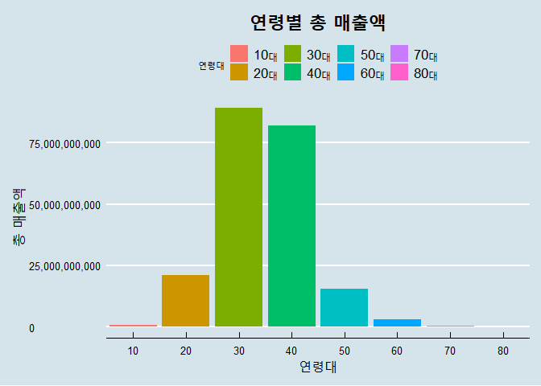

```r
# 연령대별 총 매출액 시각화
ggplot(data = age_tot) +
  geom_bar(mapping = aes(x= CLNT_AGE, y = TOT_AGE, fill = as.factor(CLNT_AGE)), stat = 'identity') +
  scale_x_discrete(limits = c(10, 20, 30, 40, 50, 60, 70, 80)) +
  scale_fill_discrete(name='연령대', labels = paste0(c('10', '20', '30', '40', '50', '60', '70', '80'), '대')) +
  labs(title = '연령별 총 매출액', x = '연령대', y = '총 매출액') +
  theme_economist() +
  theme(plot.title = element_text(face = 'bold', hjust = 0.5, size = 20, color = 'black')) +
  theme(axis.title = element_text(size = 16, color = 'black')) +
  scale_y_continuous(labels = scales::comma)
```

- 30, 40대의 총 매출액이 다른 연령대의 매출액을 다 더한 것에 약 4.28배 큼, 그러나 고객 수 자체가 커 크게 나왔으므로, 평균매출액을 시각화해봐야 한다.

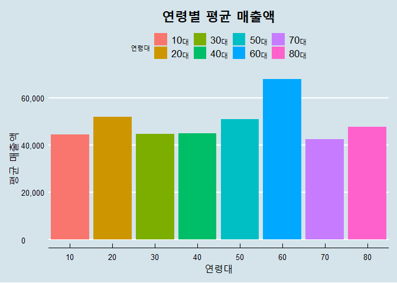

```r
# 연령대별 평균 매출액 시각화
ggplot(data = age_tot) +
  geom_bar(mapping = aes(x= CLNT_AGE, y = AVG_TOT_AGE, fill = as.factor(CLNT_AGE)), stat = 'identity') +
  scale_x_discrete(limits = c(10, 20, 30, 40, 50, 60, 70, 80)) +
  scale_fill_discrete(name='연령대', labels = paste0(c('10', '20', '30', '40', '50', '60', '70', '80'), '대')) +
  labs(title = '연령별 평균 매출액', x = '연령대', y = '평균 매출액') +
  theme_economist() +
  theme(plot.title = element_text(face = 'bold', hjust = 0.5, size = 20, color = 'black')) +
  theme(axis.title = element_text(size = 16, color = 'black')) +
  scale_y_continuous(labels = scales::comma)
```

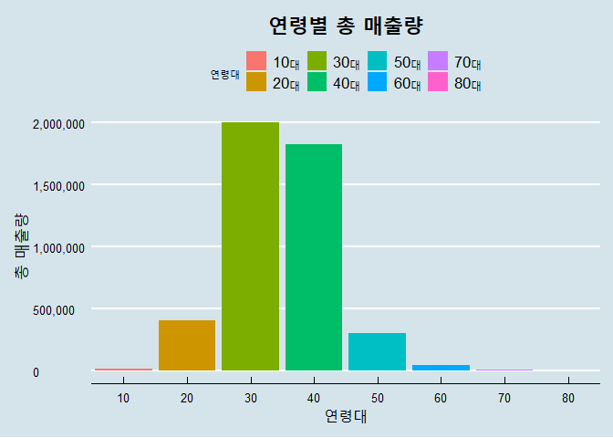

```r
# 연령대별 총 매출량 시각화
ggplot(data = age_tot) +
  geom_bar(mapping = aes(x= CLNT_AGE, y = CNT_AGE, fill = as.factor(CLNT_AGE)), stat = 'identity') +
  scale_x_discrete(limits = c(10, 20, 30, 40, 50, 60, 70, 80)) +
  scale_fill_discrete(name='연령대', labels = paste0(c('10', '20', '30', '40', '50', '60', '70', '80'), '대')) +
  labs(title = '연령별 총 매출량', x = '연령대', y = '총 매출량') +
  theme_economist() +
  theme(plot.title = element_text(face = 'bold', hjust = 0.5, size = 20, color = 'black')) +
  theme(axis.title = element_text(size = 16, color = 'black')) +
  scale_y_continuous(labels = scales::comma)
```

- 30, 40대의 총 매출량이 다른 연령대의 매출량을 다 더한 것에 약 4.98배 큼, 그러나 고객 수 자체가 커 평균값을 시각화해봐야 함.

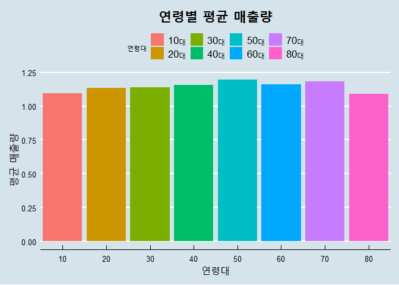

```r
# 연령대별 평균 매출량 시각화
ggplot(data=age_tot) +
  geom_bar(mapping = aes(x= CLNT_AGE, y = AVG_CNT_AGE, fill = as.factor(CLNT_AGE)), stat = 'identity') +
  scale_x_discrete(limits = c(10, 20, 30, 40, 50, 60, 70, 80)) +
  scale_fill_discrete(name='연령대', labels = paste0(c('10', '20', '30', '40', '50', '60', '70', '80'), '대')) +
  labs(title = '연령별 평균 매출량', x = '연령대', y = '평균 매출량') +
  theme_economist() +
  theme(plot.title = element_text(face = 'bold', hjust = 0.5, size = 20, color = 'black')) +
  theme(axis.title = element_text(size = 16, color = 'black')) +
  scale_y_continuous(labels = scales::comma)
```

- 평균 매출량의 경우, 미미한 차이이나 50대가 가장 높음.

```r
# 연령대별 최고 매출 TOP5 대분류 제품군 담고 있는 dataframe 생성
( ageamt_top_clac <-
    clnt_proorder %>%
      group_by(CLNT_AGE, CLAC1_NM) %>%
      summarise(SALES = sum(PD_BUY_TOT)) %>%
      arrange(CLNT_AGE, desc(SALES)) %>%
      group_by(CLNT_AGE) %>%
      slice(1:5) )
```

```
## # A tibble: 40 x 3
## # Groups:   CLNT_AGE [8]
##    CLNT_AGE CLAC1_NM             SALES
##       <dbl> <chr>                <dbl>
##  1       10 스포츠패션       175165490
##  2       10 패션잡화         153955210
##  3       10 화장품/뷰티케어  118852780
##  4       10 남성의류          32652120
##  5       10 여성의류          24133010
##  6       20 패션잡화        5032338120
##  7       20 화장품/뷰티케어 4022659410
##  8       20 스포츠패션      2587221530
##  9       20 여성의류        1826973990
## 10       20 남성의류        1191419420
## # ... with 30 more rows
```

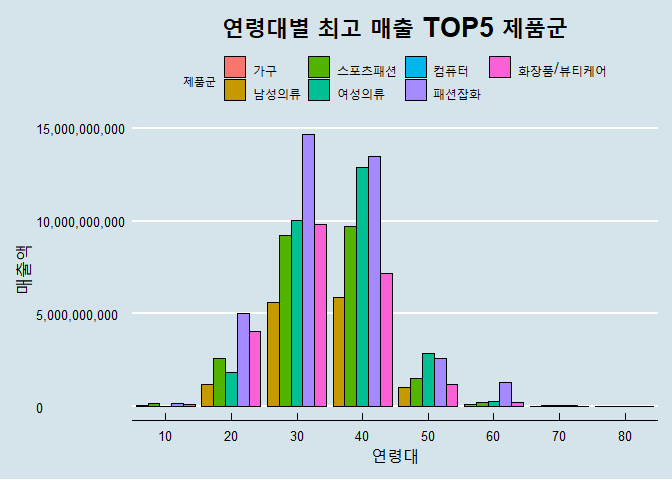

```r
# 연령대별 최고 매출 TOP5 대분류 제품군 시각화
ggplot(data = ageamt_top_clac) +
  geom_bar(mapping = aes(x=CLNT_AGE, y = SALES, fill = CLAC1_NM), position = 'dodge', stat = 'identity', col = 'black') +
  scale_x_discrete(limits = c(10, 20, 30, 40, 50, 60, 70, 80)) +
  labs(title = '연령대별 최고 매출 TOP5 제품군', x = '연령대', y = '매출액', fill = '제품군') +
  theme_economist() +
  theme(plot.title = element_text(face = 'bold', hjust = 0.5, size = 20, color = 'black')) +
  theme(axis.title = element_text(size = 16, color = 'black')) +
  scale_y_continuous(labels = scales::comma)
```

```r
# 연령대별 최다 판매 TOP3 대분류 제품군 담고 있는 dataframe 생성
( agecnt_top_clac <-
    clnt_proorder %>%
      group_by(CLNT_AGE, CLAC1_NM) %>%
      summarise(SALES = sum(PD_BUY_CT)) %>%
      arrange(CLNT_AGE, desc(SALES)) %>%
      group_by(CLNT_AGE) %>%
      slice(1:3) )
```

```
## # A tibble: 24 x 3
## # Groups:   CLNT_AGE [8]
##    CLNT_AGE CLAC1_NM          SALES
##       <dbl> <chr>             <dbl>
##  1       10 스포츠패션         3560
##  2       10 화장품/뷰티케어    3145
##  3       10 패션잡화           1614
##  4       20 화장품/뷰티케어   93573
##  5       20 스포츠패션        45399
##  6       20 패션잡화          37893
##  7       30 화장품/뷰티케어  219335
##  8       30 여성의류         204293
##  9       30 속옷/양말/홈웨어 196597
## 10       40 여성의류         255379
## # ... with 14 more rows
```

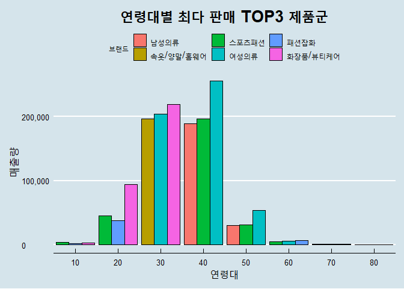

```r
# 연령대별 최다 판매 TOP3 대분류 제품군 시각화
ggplot(data = agecnt_top_clac) +
  geom_bar(mapping = aes(x=CLNT_AGE, y = SALES, fill = CLAC1_NM), position = 'dodge', stat = 'identity', col = 'black') +
  scale_x_discrete(limits = c(10, 20, 30, 40, 50, 60, 70, 80)) +
  labs(title = '연령대별 최다 판매 TOP3 제품군', x = '연령대', y = '매출량', fill = '브랜드') +
  theme_economist() +
  theme(plot.title = element_text(face = 'bold', hjust = 0.5, size = 20, color = 'black')) +
  theme(axis.title = element_text(size = 16, color = 'black')) +
  scale_y_continuous(labels = scales::comma)
```

- 70, 80대의 구매수가 현저히 적음

```r
# 연령대별 최고 매출 TOP5 브랜드 담고 있는 dataframe 생성
( ageamt_top_brand <-
    clnt_proorder %>%
      group_by(CLNT_AGE, PD_BRA_NM) %>%
      summarise(SALES = sum(PD_BUY_TOT)) %>%
      arrange(CLNT_AGE, desc(SALES)) %>%
      group_by(CLNT_AGE) %>%
      slice(1:5) )
```

```
## # A tibble: 40 x 3
## # Groups:   CLNT_AGE [8]
##    CLNT_AGE PD_BRA_NM              SALES
##       <dbl> <chr>                  <dbl>
##  1       10 나이키              35977760
##  2       10 메트로시티          16325820
##  3       10 나이키(의류)        14717200
##  4       10 메트로시티(주얼리)  13598000
##  5       10 나스                12689000
##  6       20 나이키             465867940
##  7       20 프라다             443150620
##  8       20 LG전자             409510680
##  9       20 조르지오 아르마니  326239000
## 10       20 입생로랑           321791400
## # ... with 30 more rows
```

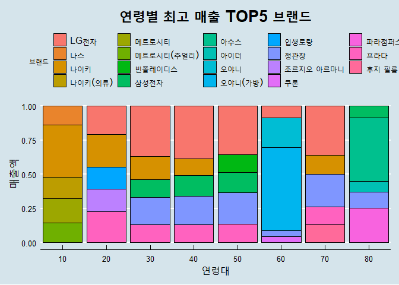

```r
# 연령대별 최고 매출 TOP5 브랜드 시각화
ggplot(data = ageamt_top_brand) +
  geom_bar(mapping = aes(x=CLNT_AGE, y = SALES, fill = PD_BRA_NM), position = 'fill', stat = 'identity', col = 'black') +
  scale_x_discrete(limits = c(10, 20, 30, 40, 50, 60, 70, 80)) +
  labs(title = '연령별 최고 매출 TOP5 브랜드', x = '연령대', y = '매출액', fill = '브랜드') +
  theme_economist() +
  theme(plot.title = element_text(face = 'bold', hjust = 0.5, size = 20, color = 'black')) +
  theme(axis.title = element_text(size = 16, color = 'black')) +
  scale_y_continuous(labels = scales::comma)
```

# 세션 데이터 탐색

## 세션 날짜 특징

```r
library(lubridate)
```

```r
library(dplyr)
library(ggplot2)
library(ggthemes)
library(scales)

# 월별 세션 생성 빈도 dataframe 생성
df_session$SESS_DT <- as.Date(df_session$SESS_DT, tz = '', tryFormats = c('%Y%m%d', '%Y-%m-%d'))
class(df_session$SESS_DT)
```

```
## [1] "Date"
```

```r
( month_sesscnt <-
  df_session %>%
    mutate(MON = paste0(month(SESS_DT), '월')) %>%
    group_by(MON) %>%
    summarise(CNT = n()) )
```

```
## # A tibble: 6 x 2
##   MON      CNT
##   <chr>  <int>
## 1 4월   390285
## 2 5월   412362
## 3 6월   411053
## 4 7월   388763
## 5 8월   322758
## 6 9월   308064
```

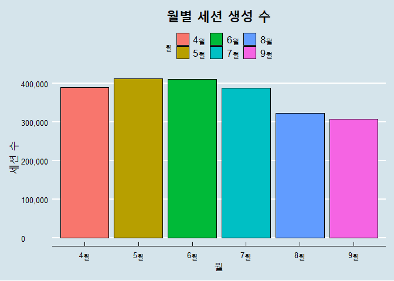

```r
# 월별 세션 생성 빈도 시각화
ggplot(data = month_sesscnt) +
  geom_bar(mapping = aes(x=MON, y = CNT, fill = as.factor(MON)), position = 'dodge', stat = 'identity', col = 'black') +
  scale_x_discrete(limits = c('4월','5월','6월','7월', '8월','9월')) +
  labs(title = '월별 세션 생성 수', x = '월', y = '세션 수', fill = '월') +
  theme_economist() +
  theme(plot.title = element_text(face = 'bold', hjust = 0.5, size = 20, color = 'black')) +
  theme(axis.title = element_text(size = 16, color = 'black')) +
  scale_y_continuous(labels = scales::comma)
```

```r
# 일자별 매출액 dataframe 생성
( day_amt <-
    sess_order %>%
    group_by(SESS_DT) %>%
    summarise(TOT_AMT_DAY = sum(PD_BUY_TOT)) )
```

```
## # A tibble: 183 x 2
##    SESS_DT    TOT_AMT_DAY
##    <date>           <dbl>
##  1 2018-04-01  1836408880
##  2 2018-04-02  1606900760
##  3 2018-04-03  1404617580
##  4 2018-04-04  1323898700
##  5 2018-04-05  1262985970
##  6 2018-04-06  1106984430
##  7 2018-04-07  1004686240
##  8 2018-04-08  1304491760
##  9 2018-04-09  1441855200
## 10 2018-04-10  1218895650
## # ... with 173 more rows
```

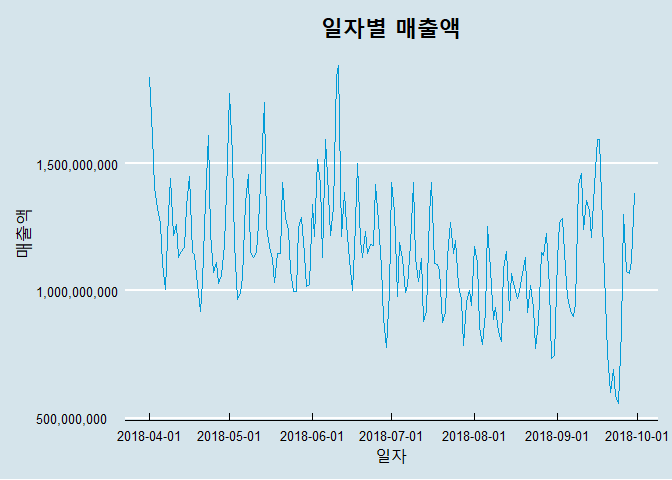

```r
# 일자별 매출액 시각화
ggplot(data = day_amt) +
  geom_line(mapping = aes(x=SESS_DT, y = TOT_AMT_DAY), colour = '#009BD7') +
  scale_x_date(breaks = seq(as.Date('2018-04-01'), as.Date('2018-10-01'), by = '1 month')) +
  labs(title = '일자별 매출액', x = '일자', y = '매출액') +
  theme_economist() +
  theme(plot.title = element_text(face = 'bold', hjust = 0.5, size = 20, color = 'black')) +
  theme(axis.title = element_text(size = 16, color = 'black')) +
  scale_y_continuous(labels = scales::comma)
```

```r
# 일자별 매출량 dataframe 생성
( day_cnt <-
    sess_order %>%
    group_by(SESS_DT) %>%
    summarise(TOT_CNT_DAY = sum(PD_BUY_CT)) )
```

```
## # A tibble: 183 x 2
##    SESS_DT    TOT_CNT_DAY
##    <date>           <dbl>
##  1 2018-04-01       36284
##  2 2018-04-02       34400
##  3 2018-04-03       32932
##  4 2018-04-04       30662
##  5 2018-04-05       31302
##  6 2018-04-06       23177
##  7 2018-04-07       21892
##  8 2018-04-08       28251
##  9 2018-04-09       31742
## 10 2018-04-10       26791
## # ... with 173 more rows
```

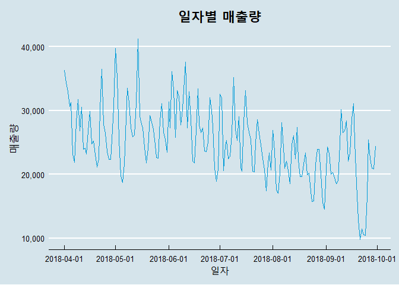

```r
# 일자별 매출량 시각화
ggplot(data = day_cnt) +
  geom_line(mapping = aes(x=SESS_DT, y = TOT_CNT_DAY), colour = '#009BD7') +
  scale_x_date(breaks = seq(as.Date('2018-04-01'), as.Date('2018-10-01'), by = '1 month')) +
  labs(title = '일자별 매출량', x = '일자', y = '매출량') +
  theme_economist() +
  theme(plot.title = element_text(face = 'bold', hjust = 0.5, size = 20, color = 'black')) +
  theme(axis.title = element_text(size = 16, color = 'black')) +
  scale_y_continuous(labels = scales::comma)
```

- 세션생성은 5,6월에 가장 많이 되며 매출액은 6월이 가장 높고 매출량은 5월이 가장 높음

```r
# 월별 최고 매출 TOP3 대분류 제품군 dataframe 생성
( monamt_top_clac <-
    sess_proorder %>%
      mutate(MON = paste0(month(SESS_DT), '월')) %>%
      group_by(MON, CLAC1_NM) %>%
      summarise(SALES = sum(PD_BUY_TOT)) %>%
      arrange(MON, desc(SALES)) %>%
      group_by(MON) %>%
      slice(1:3) )
```

```
## # A tibble: 18 x 3
## # Groups:   MON [6]
##    MON   CLAC1_NM             SALES
##    <chr> <chr>                <dbl>
##  1 4월   패션잡화        6567805940
##  2 4월   여성의류        4908453760
##  3 4월   스포츠패션      4536918390
##  4 5월   패션잡화        6841428460
##  5 5월   여성의류        4886410320
##  6 5월   스포츠패션      4425779960
##  7 6월   패션잡화        7194614960
##  8 6월   여성의류        5304063320
##  9 6월   스포츠패션      3967030340
## 10 7월   패션잡화        5855894200
## 11 7월   여성의류        4650720210
## 12 7월   화장품/뷰티케어 3538169690
## 13 8월   패션잡화        5434144680
## 14 8월   여성의류        4001584570
## 15 8월   화장품/뷰티케어 3723941210
## 16 9월   패션잡화        5363388160
## 17 9월   여성의류        4251255300
## 18 9월   스포츠패션      4037869450
```

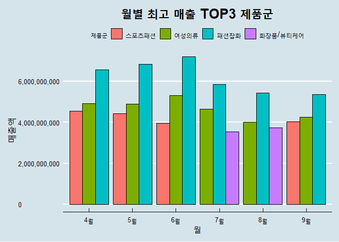

```r
# 월별 최고 매출 TOP3 대분류 제품군 시각화
ggplot(data = monamt_top_clac) +
  geom_bar(mapping = aes(x=MON, y = SALES, fill = CLAC1_NM), position = 'dodge', stat = 'identity', col = 'black') +
  labs(title = '월별 최고 매출 TOP3 제품군', x = '월', y = '매출액', fill = '제품군') +
  scale_x_discrete(limits = c('4월','5월','6월','7월', '8월','9월')) +
  theme_economist() +
  theme(plot.title = element_text(face = 'bold', hjust = 0.5, size = 20, color = 'black')) +
  theme(axis.title = element_text(size = 16, color = 'black')) +
  scale_y_continuous(labels = scales::comma)
```

- 패션잡화가 압도적으로 6개월 내내 가장 큰 수익을 냄. 2순위는 모두 여성의류로 동일. 총 37개의 제품군이 있지만 높은 매출을 내는 제품군은 한정되어 있다는 것을 알 수 있음

```r
# 더 상세하게 보기 위해, 중분류로 살펴보고자 한다.
# 월별 최고 매출 TOP3 중분류 제품군 dataframe 생성
( monamt_top_clac2 <-
    sess_proorder %>%
      mutate(MON = paste0(month(SESS_DT), '월')) %>%
      group_by(MON, CLAC2_NM) %>%
      summarise(SALES = sum(PD_BUY_TOT)) %>%
      arrange(MON, desc(SALES)) %>%
      group_by(MON) %>%
      slice(1:3) )
```

```
## # A tibble: 18 x 3
## # Groups:   MON [6]
##    MON   CLAC2_NM               SALES
##    <chr> <chr>                  <dbl>
##  1 4월   여성가방          2113685160
##  2 4월   남성의류상의      1768276940
##  3 4월   스킨케어          1713728940
##  4 5월   여성가방          2032620900
##  5 5월   여성의류상의      1821749470
##  6 5월   남성의류상의      1798172670
##  7 6월   여성가방          1998632680
##  8 6월   여성화            1987467590
##  9 6월   여성의류상의      1900488400
## 10 7월   여성의류전신      1785676270
## 11 7월   여성가방          1717596410
## 12 7월   냉방가전          1573527100
## 13 8월   여성가방          1971223880
## 14 8월   메이크업          1614038820
## 15 8월   스킨케어          1550033530
## 16 9월   여성가방          1870334480
## 17 9월   스킨케어          1691293070
## 18 9월   홍삼/인삼가공식품 1636667070
```

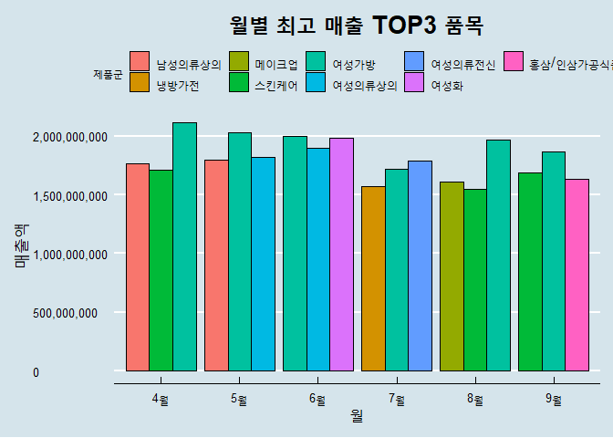

```r
# 월별 최고 매출 TOP3 중분류 제품군 시각화
ggplot(data = monamt_top_clac2) +
  geom_bar(mapping = aes(x=MON, y = SALES, fill = CLAC2_NM), position = 'dodge', stat = 'identity', col = 'black') +
  labs(title = '월별 최고 매출 TOP3 품목', x = '월', y = '매출액', fill = '제품군') +
  scale_x_discrete(limits = c('4월','5월','6월','7월', '8월','9월')) +
  theme_economist() +
  theme(plot.title = element_text(face = 'bold', hjust = 0.5, size = 20, color = 'black')) +
  theme(axis.title = element_text(size = 16, color = 'black')) +
  scale_y_continuous(labels = scales::comma)
```

- 패션잡화 매출이 6개월 동안 가장 높았던 이유는 여성가방 때문이었음을 알 수 있음. 9월은 추석의 여팔 다른 달에 비해 유달리 홍삼품목의 매출이 높았을 것으로 예상됨. 8월은 여름휴가로 선크림 또는 워터프루프와 같은 화장품을 많이 사는 것으로 예상됨. 월별로 제품 추천해줘도 좋을 듯.

```r
# 월별 최다 판매 TOP3 대분류 제품군 dataframe 생성
( moncnt_top_clac <-
    sess_proorder %>%
      mutate(MON = paste0(month(SESS_DT), '월')) %>%
      group_by(MON, CLAC1_NM) %>%
      summarise(SALES = sum(PD_BUY_CT)) %>%
      arrange(MON, desc(SALES)) %>%
      group_by(MON) %>%
      slice(1:3) )
```

```
## # A tibble: 18 x 3
## # Groups:   MON [6]
##    MON   CLAC1_NM          SALES
##    <chr> <chr>             <dbl>
##  1 4월   여성의류          98521
##  2 4월   스포츠패션        87984
##  3 4월   남성의류          86664
##  4 5월   여성의류         104318
##  5 5월   화장품/뷰티케어   95535
##  6 5월   스포츠패션        91565
##  7 6월   여성의류         110249
##  8 6월   화장품/뷰티케어   90255
##  9 6월   스포츠패션        87851
## 10 7월   여성의류          99462
## 11 7월   화장품/뷰티케어   82767
## 12 7월   스포츠패션        76932
## 13 8월   화장품/뷰티케어   85444
## 14 8월   여성의류          72193
## 15 8월   속옷/양말/홈웨어  58454
## 16 9월   화장품/뷰티케어   74602
## 17 9월   여성의류          70418
## 18 9월   스포츠패션        59393
```

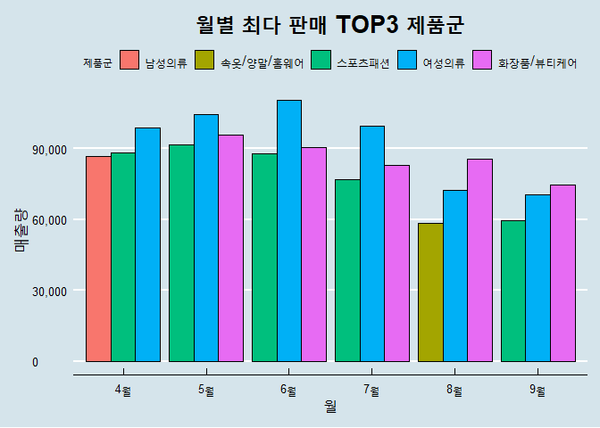

```r
# 월별 최다 판매 TOP3 대분류 제품군 시각화
ggplot(data = moncnt_top_clac) +
  geom_bar(mapping = aes(x=MON, y = SALES, fill = CLAC1_NM), position = 'dodge', stat = 'identity', col = 'black') +
  labs(title = '월별 최다 판매 TOP3 제품군', x = '월', y = '매출량', fill = '제품군') +
  scale_x_discrete(limits = c('4월','5월','6월','7월', '8월','9월')) +
  theme_economist() +
  theme(plot.title = element_text(face = 'bold', hjust = 0.5, size = 20, color = 'black')) +
  theme(axis.title = element_text(size = 16, color = 'black')) +
  scale_y_continuous(labels = scales::comma)
```

- 8월 속옷/양말/홈웨어가 새로운 제품군으로 등장한 것으로 보아, - 여름철에 자주 세탁을 해야하므로 많이 필요하기 떄문에 매출량이 증가한 것으로 짐작할 수 있다.

```r
# 월별 최고 매출 TOP3 브랜드 dataframe 생성
( monamt_top_brand <-
    sess_proorder %>%
      mutate(MON = paste0(month(SESS_DT), '월')) %>%
      group_by(MON, PD_BRA_NM) %>%
      summarise(SALES = sum(PD_BUY_TOT)) %>%
      arrange(MON, desc(SALES)) %>%
      group_by(MON) %>%
      slice(1:3) )
```

```
## # A tibble: 18 x 3
## # Groups:   MON [6]
##    MON   PD_BRA_NM      SALES
##    <chr> <chr>          <dbl>
##  1 4월   LG전자    1244366300
##  2 4월   나이키     605096020
##  3 4월   정관장     570597500
##  4 5월   LG전자    1410901271
##  5 5월   정관장     663034700
##  6 5월   삼성전자   513525480
##  7 6월   LG전자    1713053400
##  8 6월   나이키     570501330
##  9 6월   정관장     545414000
## 10 7월   LG전자    1517244410
## 11 7월   삼성전자   815361930
## 12 7월   나이키     570797500
## 13 8월   LG전자    1125959360
## 14 8월   프라다     566436600
## 15 8월   정관장     512676800
## 16 9월   정관장    1597776170
## 17 9월   LG전자     765839920
## 18 9월   나이키     597545520
```

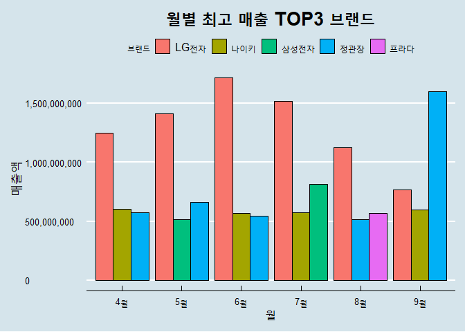

```r
# 월별 최고 매출 TOP3 브랜드 시각화
ggplot(data = monamt_top_brand) +
  geom_bar(mapping = aes(x=MON, y = SALES, fill = PD_BRA_NM), position = 'dodge', stat = 'identity', col = 'black') +
  labs(title = '월별 최고 매출 TOP3 브랜드', x = '월', y = '매출액', fill = '브랜드') +
  scale_x_discrete(limits = c('4월','5월','6월','7월', '8월','9월')) +
  theme_economist() +
  theme(plot.title = element_text(face = 'bold', hjust = 0.5, size = 20, color = 'black')) +
  theme(axis.title = element_text(size = 16, color = 'black')) +
  scale_y_continuous(labels = scales::comma)
```

```r
# 월별 최다 판매 TOP3 브랜드 dataframe 생성
( moncnt_top_brand <-
    sess_proorder %>%
      mutate(MON = paste0(month(SESS_DT), '월')) %>%
      group_by(MON, PD_BRA_NM) %>%
      summarise(SALES = sum(PD_BUY_CT)) %>%
      arrange(MON, desc(SALES)) %>%
      group_by(MON) %>%
      slice(1:3) )
```

```
## # A tibble: 18 x 3
## # Groups:   MON [6]
##    MON   PD_BRA_NM    SALES
##    <chr> <chr>        <dbl>
##  1 4월   지오다노     14385
##  2 4월   에이치커넥트  8057
##  3 4월   나이키        7806
##  4 5월   지오다노     15475
##  5 5월   크록스        8127
##  6 5월   에이치커넥트  6987
##  7 6월   지오다노     15429
##  8 6월   나이키        9982
##  9 6월   크록스        7340
## 10 7월   지오다노     13131
## 11 7월   나이키       11166
## 12 7월   탑텐          7239
## 13 8월   지오다노      8005
## 14 8월   한샘          7411
## 15 8월   탑텐          7239
## 16 9월   정관장       12795
## 17 9월   지오다노     10475
## 18 9월   나이키        7919
```

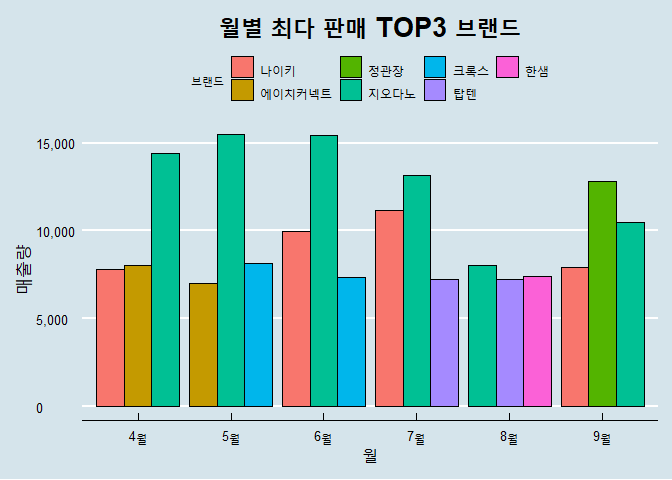

```r
# 월별 최다 판매 TOP3 브랜드 시각화
ggplot(data = moncnt_top_brand) +
  geom_bar(mapping = aes(x=MON, y = SALES, fill = PD_BRA_NM), position = 'dodge', stat = 'identity', col = 'black') +
  labs(title = '월별 최다 판매 TOP3 브랜드', x = '월', y = '매출량', fill = '브랜드') +
  scale_x_discrete(limits = c('4월','5월','6월','7월', '8월','9월')) +
  theme_economist() +
  theme(plot.title = element_text(face = 'bold', hjust = 0.5, size = 20, color = 'black')) +
  theme(axis.title = element_text(size = 16, color = 'black')) +
  scale_y_continuous(labels = scales::comma)
```

## 기기 유형별 특징

```r
# 기기 유형별 세션 수
table(df_session$DVC_CTG_NM)
```

```
##
## desktop  mobile  tablet
##    1192 2221685   10408
```

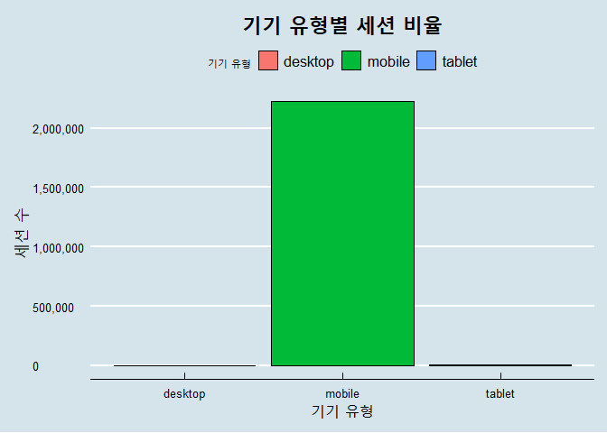

```r
# 기기 유형별 세션 비율 시각화
library(ggplot2)
library(ggthemes)
library(scales)

ggplot(data = df_session) +
  geom_bar(mapping = aes(x=DVC_CTG_NM, fill=DVC_CTG_NM), position = 'dodge', col = 'black') +
  scale_fill_discrete(name='기기 유형') +
  labs(title = '기기 유형별 세션 비율', x = '기기 유형', y = '세션 수') +
  theme_economist() +
  theme(plot.title = element_text(face = 'bold', hjust = 0.5, size = 20, color = 'black')) +
  theme(axis.title = element_text(size = 16, color = 'black')) +
  scale_y_continuous(labels = scales::comma)
```

```r
# 기기 유형별 매출액
( dvc_tot <- sess_order %>%
    group_by(DVC_CTG_NM) %>%
    summarise(TOT_DVC = sum(PD_BUY_TOT), # 기기별 매출액 총합
              CNT_DVC = sum(PD_BUY_CT),  # 기기별 매출수량 총합
              AVG_CNT_DVC = mean(PD_BUY_CT)) %>%  # 기기별 매출수량 평균
    mutate(AVG_TOT_DVC = TOT_DVC / CNT_DVC) # 기기별 매출액 평균
)
```

```
## # A tibble: 3 x 5
##   DVC_CTG_NM      TOT_DVC CNT_DVC AVG_CNT_DVC AVG_TOT_DVC
##   <chr>             <dbl>   <dbl>       <dbl>       <dbl>
## 1 desktop       187381291    4215        1.03      44456.
## 2 mobile     210006392320 4560595        1.15      46048.
## 3 tablet        955113560   23523        1.20      40603.
```

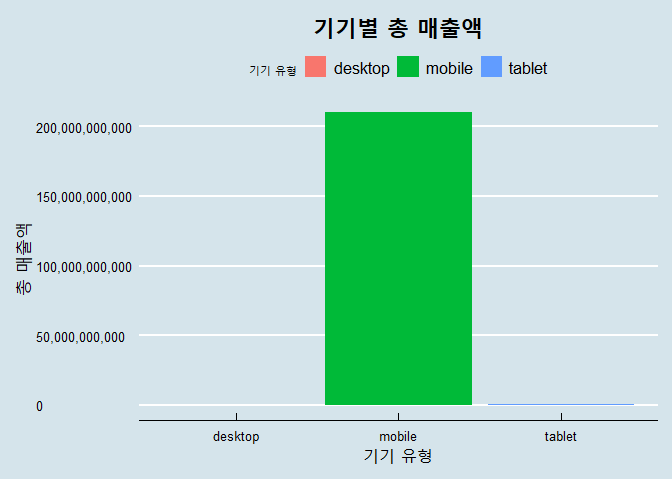

```r
# 기기별 총 매출액 시각화
ggplot(data = dvc_tot) +
  geom_bar(mapping = aes(x= DVC_CTG_NM, y = TOT_DVC, fill = DVC_CTG_NM), stat = 'identity') +
  scale_fill_discrete(name='기기 유형') +
  labs(title = '기기별 총 매출액', x = '기기 유형', y = '총 매출액') +
  theme_economist() +
  theme(plot.title = element_text(face = 'bold', hjust = 0.5, size = 20, color = 'black')) +
  theme(axis.title = element_text(size = 16, color = 'black')) +
  scale_y_continuous(labels = scales::comma)
```

- mobile의 총 매출액이 가장 큼, 그러나 비율 자체가 커 크게 나온 값이므로 평균값으로 시각화 필요

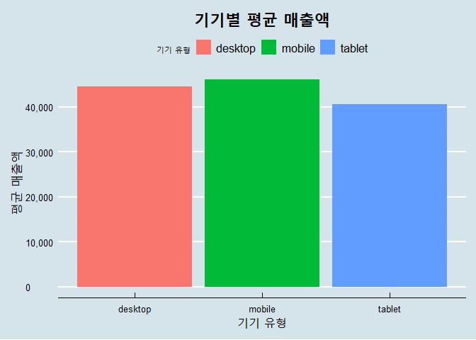

```r
# 기기별 평균 매출액 시각화
ggplot(data=dvc_tot) +
  geom_bar(mapping = aes(x= DVC_CTG_NM, y = AVG_TOT_DVC, fill = DVC_CTG_NM), stat = 'identity') +
  scale_fill_discrete(name='기기 유형') +
  labs(title = '기기별 평균 매출액', x = '기기 유형', y = '평균 매출액') +
  theme_economist() +
  theme(plot.title = element_text(face = 'bold', hjust = 0.5, size = 20, color = 'black')) +
  theme(axis.title = element_text(size = 16, color = 'black')) +
  scale_y_continuous(labels = scales::comma)
```

```r
# 차이가 미미하나 mobile의 평균 매출액이 가장 큼
```

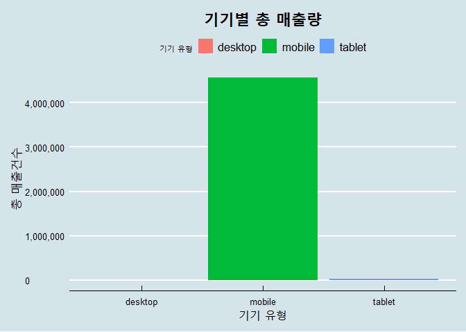

```r
# 기기별 총 매출건수 시각화
ggplot(data = dvc_tot) +
  geom_bar(mapping = aes(x= DVC_CTG_NM, y = CNT_DVC, fill = DVC_CTG_NM), stat = 'identity') +
  scale_fill_discrete(name='기기 유형') +
  labs(title = '기기별 총 매출량', x = '기기 유형', y = '총 매출건수') +
  theme_economist() +
  theme(plot.title = element_text(face = 'bold', hjust = 0.5, size = 20, color = 'black')) +
  theme(axis.title = element_text(size = 16, color = 'black')) +
  scale_y_continuous(labels = scales::comma)
```

```r
# mobile의 총 매출량이 가장 큼, 그러나 비율 자체가 커 크게 나온 값이므로 평균값으로 시각화 필요
```

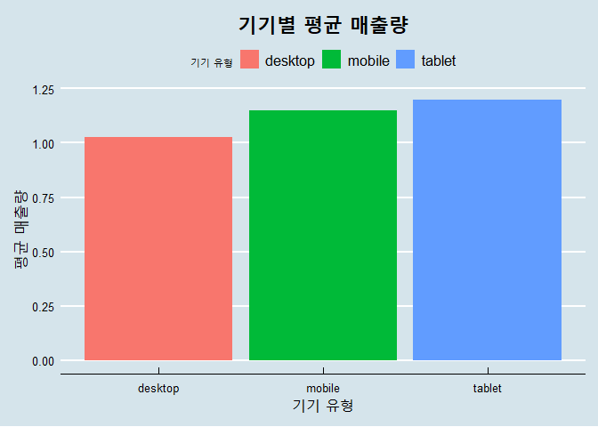

```r
# 기기별 평균 매출량 시각화
ggplot(data=dvc_tot) +
  geom_bar(mapping = aes(x= DVC_CTG_NM, y = AVG_CNT_DVC, fill = DVC_CTG_NM), stat = 'identity') +
  scale_fill_discrete(name='기기 유형') +
  labs(title = '기기별 평균 매출량', x = '기기 유형', y = '평균 매출량') +
  theme_economist() +
  theme(plot.title = element_text(face = 'bold', hjust = 0.5, size = 20, color = 'black')) +
  theme(axis.title = element_text(size = 16, color = 'black')) +
  scale_y_continuous(labels = scales::comma)
```

```r
# 차이가 미미하나 tablet의 평균 매출량이 가장 많다
```

# 상품 데이터 탐색

## 상품 분류별 특징

```r
# 최고 매출 대분류 제품군 담고 있는 dataframe 생성
( amt_top_clac <-
    prod_order %>%
      group_by(CLAC1_NM) %>%
      summarise(SALES = sum(PD_BUY_TOT)) %>%
      arrange(desc(SALES)) %>%
      slice(1:10) )
```

```
## # A tibble: 10 x 2
##    CLAC1_NM               SALES
##    <chr>                  <dbl>
##  1 패션잡화         37257276400
##  2 여성의류         28002487480
##  3 스포츠패션       23426339670
##  4 화장품/뷰티케어  22574445460
##  5 남성의류         13916530070
##  6 가구              9652045210
##  7 유아동의류        8317986500
##  8 생활/주방가전     7882762950
##  9 건강식품          7379826400
## 10 속옷/양말/홈웨어  5688794400
```

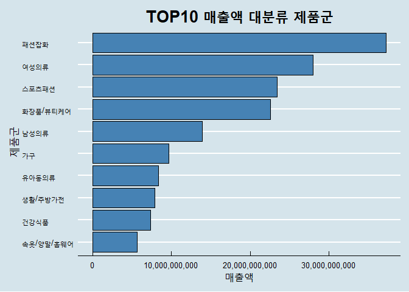

```r
# 최고 매출 10개 대분류 제품군 시각화
ggplot(data = amt_top_clac, aes(reorder(CLAC1_NM, SALES, identity), SALES)) +
  geom_col(fill = 'steelblue', col = 'black') +
  labs(title = 'TOP10 매출액 대분류 제품군', x = '제품군', y = '매출액') +
  scale_fill_discrete(name = '제품군') +
  coord_flip() +
  theme_economist() +
  theme(plot.title = element_text(face = 'bold', hjust = 0.5, size = 20, color = 'black')) +
  theme(axis.title = element_text(size = 16, color = 'black')) +
  scale_y_continuous(labels = scales::comma)
```

```r
# 최다 판매 대분류 제품군 담고 있는 dataframe 생성
( cnt_top_clac <-
    prod_order %>%
      group_by(CLAC1_NM) %>%
      summarise(SALES = sum(PD_BUY_CT)) %>%
      arrange(desc(SALES)) %>%
      slice(1:10) )
```

```
## # A tibble: 10 x 2
##    CLAC1_NM          SALES
##    <chr>             <dbl>
##  1 여성의류         555161
##  2 화장품/뷰티케어  512522
##  3 스포츠패션       459423
##  4 남성의류         429489
##  5 속옷/양말/홈웨어 424633
##  6 패션잡화         385716
##  7 유아동의류       288458
##  8 출산/육아용품    146647
##  9 퍼스널케어       138149
## 10 시즌스포츠       125489
```

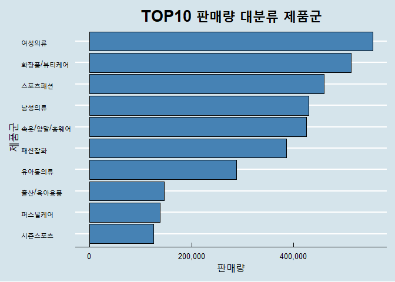

```r
# 최다 판매 대분류 제품군 시각화
ggplot(data = cnt_top_clac, aes(reorder(CLAC1_NM, SALES, identity), SALES)) +
  geom_col(fill = 'steelblue', col = 'black') +
  labs(title = 'TOP10 판매량 대분류 제품군', x = '제품군', y = '판매량') +
  scale_fill_discrete(name = '제품군') +
  coord_flip() +
  theme_economist() +
  theme(plot.title = element_text(face = 'bold', hjust = 0.5, size = 20, color = 'black')) +
  theme(axis.title = element_text(size = 16, color = 'black')) +
  scale_y_continuous(labels = scales::comma)
```

```r
# 최고 매출 중분류 제품군 담고 있는 dataframe 생성
( amt_top_clac2 <-
    prod_order %>%
      group_by(CLAC2_NM) %>%
      summarise(SALES = sum(PD_BUY_TOT)) %>%
      arrange(desc(SALES)) %>%
      slice(1:10) )
```

```
## # A tibble: 10 x 2
##    CLAC2_NM                SALES
##    <chr>                   <dbl>
##  1 여성가방          11704093510
##  2 스킨케어           9793913350
##  3 여성의류상의       9653091690
##  4 메이크업           9199989460
##  5 남성의류상의       8951874380
##  6 여성화             8709559730
##  7 여성의류전신       8384147230
##  8 여성의류아우터     5577300190
##  9 홍삼/인삼가공식품  4464528690
## 10 여성의류하의       4387948370
```

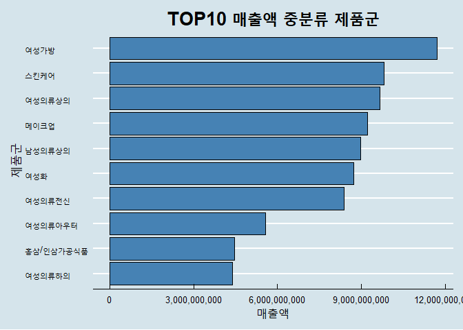

```r
# 최고 매출 10개 중분류 제품군 시각화
ggplot(data = amt_top_clac2, aes(reorder(CLAC2_NM, SALES, identity), SALES)) +
  geom_col(fill = 'steelblue', col = 'black') +
  labs(title = 'TOP10 매출액 중분류 제품군', x = '제품군', y = '매출액') +
  scale_fill_discrete(name = '제품군') +
  coord_flip() +
  theme_economist() +
  theme(plot.title = element_text(face = 'bold', hjust = 0.5, size = 20, color = 'black')) +
  theme(axis.title = element_text(size = 16, color = 'black')) +
  scale_y_continuous(labels = scales::comma)
```

```r
# 최다 판매 중분류 제품군 담고 있는 dataframe 생성
( cnt_top_clac2 <-
    prod_order %>%
    group_by(CLAC2_NM) %>%
    summarise(SALES = sum(PD_BUY_CT)) %>%
    arrange(desc(SALES)) %>%
    slice(1:10) )
```

```
## # A tibble: 10 x 2
##    CLAC2_NM      SALES
##    <chr>         <dbl>
##  1 남성의류상의 303065
##  2 여성의류상의 256723
##  3 메이크업     227826
##  4 스킨케어     197017
##  5 여성속옷     165007
##  6 여성의류전신 133623
##  7 수영/물놀이  125489
##  8 여성의류하의 116060
##  9 남성의류하의 103410
## 10 여성화       103064
```

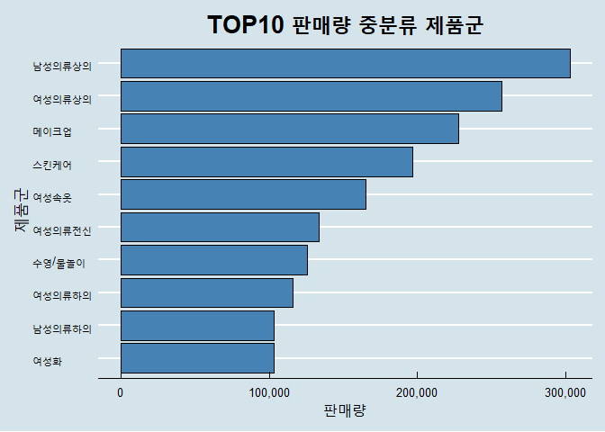

```r
# 최다 판매 대분류 제품군 시각화
ggplot(data = cnt_top_clac2, aes(reorder(CLAC2_NM, SALES, identity), SALES)) +
  geom_col(fill = 'steelblue', col = 'black') +
  labs(title = 'TOP10 판매량 중분류 제품군', x = '제품군', y = '판매량') +
  scale_fill_discrete(name = '제품군') +
  coord_flip() +
  theme_economist() +
  theme(plot.title = element_text(face = 'bold', hjust = 0.5, size = 20, color = 'black')) +
  theme(axis.title = element_text(size = 16, color = 'black')) +
  scale_y_continuous(labels = scales::comma)
```

```r
# 최고 매출 소분류 제품군 담고 있는 dataframe 생성
( amt_top_clac3 <-
    prod_order %>%
    group_by(CLAC3_NM) %>%
    summarise(SALES = sum(PD_BUY_TOT)) %>%
    arrange(desc(SALES)) %>%
    slice(1:10) )
```

```
## # A tibble: 10 x 2
##    CLAC3_NM                    SALES
##    <chr>                       <dbl>
##  1 여성원피스             8259440530
##  2 남성티셔츠             6219268520
##  3 여성숄더백             5155451940
##  4 스킨케어세트           4607495600
##  5 여성남방셔츠           4224663790
##  6 여성티셔츠/탑          3448977980
##  7 여성토트백             3338530880
##  8 BB/파운데이션/컴팩트류 2837843940
##  9 남성런닝/트레이닝화    2700261530
## 10 홍삼액                 2500091770
```

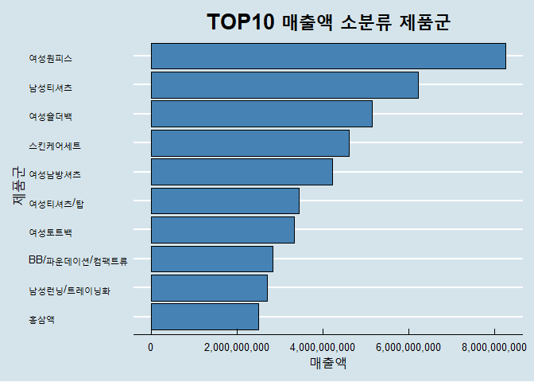

```r
# 최고 매출 10개 소분류 제품군 시각화
ggplot(data = amt_top_clac3, aes(reorder(CLAC3_NM, SALES, identity), SALES)) +
  geom_col(fill = 'steelblue', col = 'black') +
  labs(title = 'TOP10 매출액 소분류 제품군', x = '제품군', y = '매출액') +
  scale_fill_discrete(name = '제품군') +
  coord_flip() +
  theme_economist() +
  theme(plot.title = element_text(face = 'bold', hjust = 0.5, size = 20, color = 'black')) +
  theme(axis.title = element_text(size = 16, color = 'black')) +
  scale_y_continuous(labels = scales::comma)
```

```r
# 최다 판매 소분류 제품군 담고 있는 dataframe 생성
( cnt_top_clac3 <-
    prod_order %>%
    group_by(CLAC3_NM) %>%
    summarise(SALES = sum(PD_BUY_CT)) %>%
    arrange(desc(SALES)) %>%
    slice(1:10) )
```

```
## # A tibble: 10 x 2
##    CLAC3_NM                  SALES
##    <chr>                     <dbl>
##  1 남성티셔츠               245835
##  2 여성원피스               131225
##  3 여성티셔츠/탑            113180
##  4 여성남방셔츠              96953
##  5 남성캐주얼바지            87197
##  6 여성바지                  66838
##  7 블라인드/버티컬           59173
##  8 블러셔/쉐이딩/하이라이터  57631
##  9 BB/파운데이션/컴팩트류    55742
## 10 스킨케어세트              50715
```

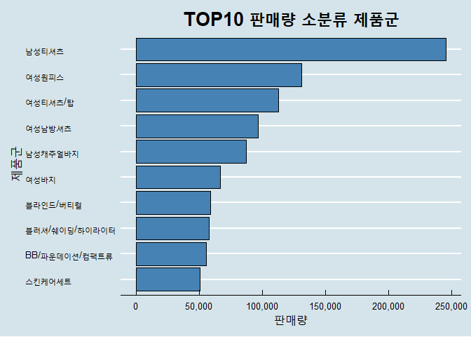

```r
# 최다 판매 대분류 제품군 시각화
ggplot(data = cnt_top_clac3, aes(reorder(CLAC3_NM, SALES, identity), SALES)) +
  geom_col(fill = 'steelblue', col = 'black') +
  labs(title = 'TOP10 판매량 소분류 제품군', x = '제품군', y = '판매량') +
  scale_fill_discrete(name = '제품군') +
  coord_flip() +
  theme_economist() +
  theme(plot.title = element_text(face = 'bold', hjust = 0.5, size = 20, color = 'black')) +
  theme(axis.title = element_text(size = 16, color = 'black')) +
  scale_y_continuous(labels = scales::comma)
```

## 브랜드별 특징

```r
# 최고 매출 브랜드 dataframe 생성
( amt_top_brand <-
    prod_order %>%
      group_by(PD_BRA_NM) %>%
      summarise(SALES = sum(PD_BUY_TOT)) %>%
      arrange(desc(SALES)) )
```

```
## # A tibble: 13,220 x 2
##    PD_BRA_NM         SALES
##    <chr>             <dbl>
##  1 LG전자       7777364661
##  2 정관장       4346813170
##  3 나이키       3139784550
##  4 프라다       3013931110
##  5 삼성전자     2997201810
##  6 다이슨       1925193500
##  7 빈폴레이디스 1805578240
##  8 에고이스트   1524920040
##  9 설화수       1372381000
## 10 입생로랑     1310801700
## # ... with 13,210 more rows
```

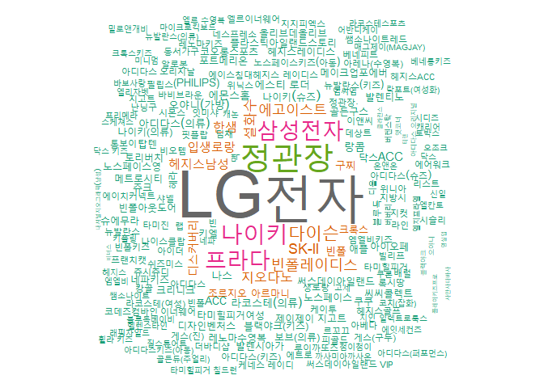

```r
# 최고 매출 브랜드  시각화
library(wordcloud)
pal <- brewer.pal(8, 'Dark2')

set.seed(14)

wordcloud(words = amt_top_brand$PD_BRA_NM,
          freq = amt_top_brand$SALES,
          min.freq = 5000,
          max.words = 200,
          random.order = F,
          rot.per = .1,
          scale = c(5, 0.5),
          colors = pal)
```

```r
# 최다 판매 브랜드 dataframe 생성
( cnt_top_brand <-
    prod_order %>%
    group_by(PD_BRA_NM) %>%
    summarise(SALES = sum(PD_BUY_CT)) %>%
    arrange(desc(SALES)) )
```

```
## # A tibble: 13,220 x 2
##    PD_BRA_NM      SALES
##    <chr>          <dbl>
##  1 지오다노       76900
##  2 나이키         49033
##  3 정관장         34745
##  4 한샘           34287
##  5 에이치커넥트   33078
##  6 탑텐           32293
##  7 크록스         30306
##  8 가쯔           25993
##  9 입생로랑       25889
## 10 아디다스(의류) 25504
## # ... with 13,210 more rows
```

```r
cnt_top_brandwc <- data.frame(
  word = cnt_top_brand$PD_BRA_NM,
  freq = cnt_top_brand$SALES
)
```

```r
# 최다 판매 브랜드  시각화
library(wordcloud2)

# knit시 출력되지 않음
wordcloud2(cnt_top_brandwc[1:200, ], shape = 'circle', color = pal)
```

[interactive chart not shown]

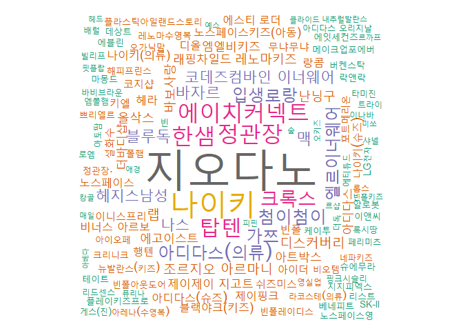

```r
# wordcloud로 출력
library(wordcloud)

wordcloud(words = cnt_top_brand$PD_BRA_NM,
          freq = cnt_top_brand$SALES,
          min.freq = 5000,
          max.words = 200,
          random.order = F,
          rot.per = .1,
          scale = c(5, 0.5),
          colors = pal)
```

- 정제되지 않은 브랜드명 합쳐야 함.